# Statistical Inference Using Exponential Distribution

maverix13

September 27, 2015

# Overview

This report investigates exponential distribution in R to demonstrate comparison with Central Limit Theorem. In this report, comparison is provided for mean, variance and mean distribution to compare simulated data with that of theoretical computations. Finally, a comparison of the distribution of a large collection of random exponentials and the distribution of a large collection of averages of 40 exponentials is presented.

# Simulation

The exponential distribution can be simulated in R with rexp(n, lambda) where lambda is the rate parameter. The mean of exponential distribution is 1/lambda and the standard deviation is also 1/lambda. Lambda is set to 0.2 for all of the simulations. Investigation is done on the distribution of averages of 40 exponentials and a total of 1000 simulations are executed.

```
## stat_bin: binwidth defaulted to range/30. Use 'binwidth = x' to adjust this.
```

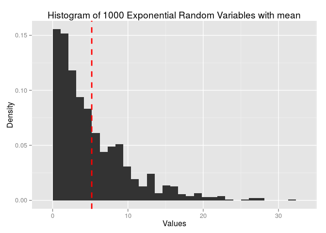

```r
library(ggplot2)
set.seed(123)
lambda <- 0.2
n <- 40
numSimulations <- 1000
simulatedMeans <- NULL
for (i in 1:numSimulations) simulatedMeans = c(simulatedMeans, mean(rexp(40, lambda)))
values <- rexp(1000, lambda)
ggplot(data.frame(values), aes(x=values)) +
  geom_histogram(aes(y=..density..)) +
  stat_function(fun = dexp, args=list(mean=5, sd=5), colour = "red") +
  xlab("Values") + ylab("Density") +
  geom_vline(aes(xintercept=mean(values)), color="red", linetype="dashed", size=1) +
  ggtitle("Histogram of 1000 Exponential Random Variables with mean")
```

# Sample Mean versus Theoretical Mean

This section compares the simulated mean with theoretical mean. The mean of exponential distribution is 1/lambda.

```r
theoreticalMean <- 1/lambda # Value is 5
simulatedMean <- mean(simulatedMeans)
```

In comparison to theoretical mean 5, simulated mean is centered at 5.0119113

```
## stat_bin: binwidth defaulted to range/30. Use 'binwidth = x' to adjust this.
```

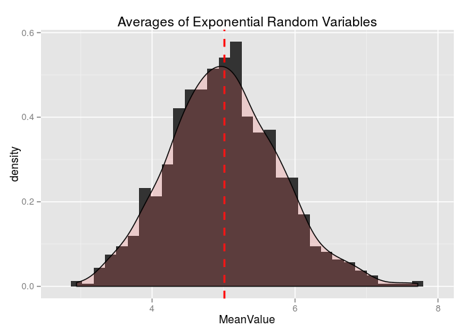

```r
df <- data.frame(simulatedMeans)
colnames(df) <- c("MeanValue")
ggplot(df, aes(x=MeanValue)) + ggtitle("Averages of Exponential Random Variables") +
  geom_histogram(aes(y=..density..)) +
  geom_vline(aes(xintercept=simulatedMean), color="red", linetype="dashed", size=1) +
  geom_density(alpha=.2, fill="#FF6666")
```

# Sample Variance versus Theoretical Variance

The standard deviation of expoenetial distribution is also 1/lambda. According to Central Limit theorem, one useful way to think about is that sample average is approximately normally distributed with N(mu, sigma^2/n) where mu and sigma are theoretical mean and standard deviation.

```r
theoreticalVar <- (1/lambda)^2
simulatedVar <- var(simulatedMeans) * n
```

In comparison to theoretical variance 25, simulated variance of the distribution is 24.0197135. According to CLT, as the number of simulation increases the sample averages should approach to normal distribution with mean and standard deviation close to theoretical values. Based on the previous statement, conclusion can be drawn that instead of 1000 simulations, if there are million simulations simulated and theoretical variance should be close to each other.

# Distribution